# Polskie firmy na JRC

Dominik Batorski

30 stycznia 2018

## Zamówienia przez sieć

Polska jest na jednym z ostatnich miejsc w Unii Europejskiej pod względem liczby firm, które otrzymują zamówienia przez internet. W 2016 roku tylko 12% firm zatrudniających przynajmniej 10 osób otrzymywało zamówienia tą drogą. Tymczasem średnia dla krajów Unii wynosi 20%.

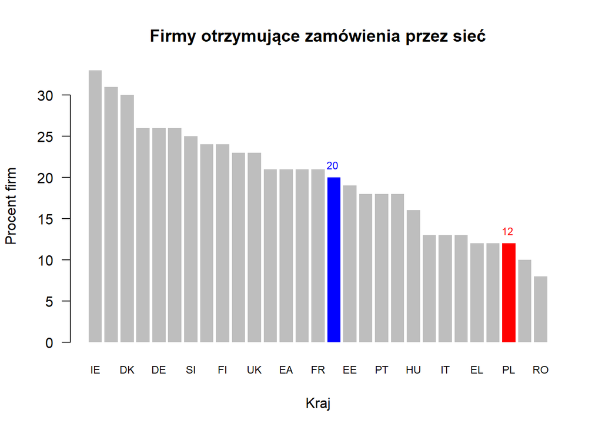

Co więcej, jeśli przyjrzeć się zmianom zachodzącym w czasie, to okaże się, że polskie firmy znacznie wolniej niż firmy w innych krajach zwiększają częstość tego typu zamówień.

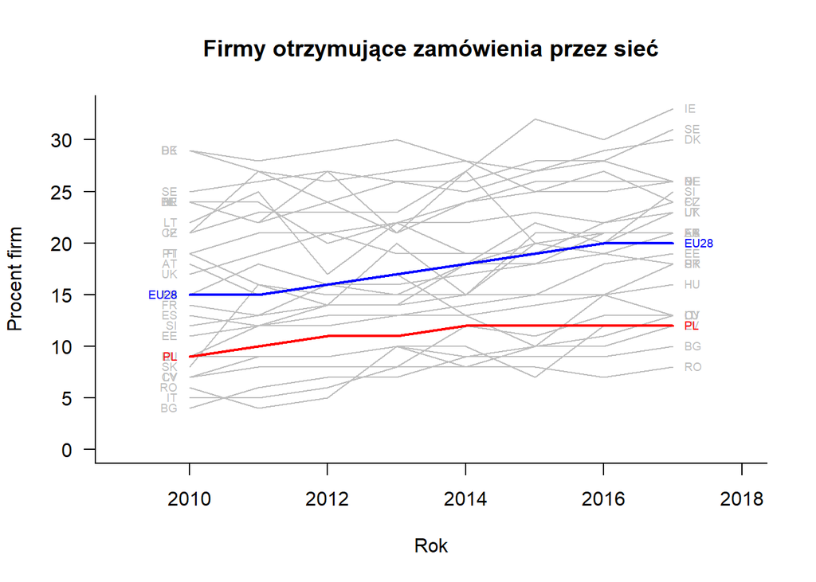

Różnice są stosunkowo duże bez względu na wielkość firm. Dla największych firm zatrudniających przynajmniej 250 osób zamówienia drogą elektroniczną odbiera 36% firm w Polsce i 44% w UE. Dla firm średnich jest to odpowiednio 19% i 29%, a dla małych 10% i 18%. Warto jednak zwrócić uwagę, że w przypadku największych firm osiem innych państw w Unii ma gorsze wyniki, natomiast w przypadku najmniejszych tylko Bułgaria i Rumunia znajdują się niżej.

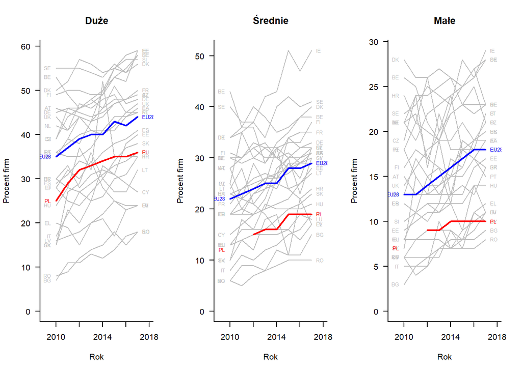

## Sprzedaż w internecie

Większe znaczenie niż same zamówienia przez sieć ma sprzedaż online. W 2017 roku tylko 10% polskich firm miało ze sprzedaży przez internet przynajmniej 1% swoich przychodów. W tym czasie średnia dla Unii Europejskiej wynosiła 18%. Tylko cztery państwa w UE mają mniejszy odsetek firm zarabiających w sieci.

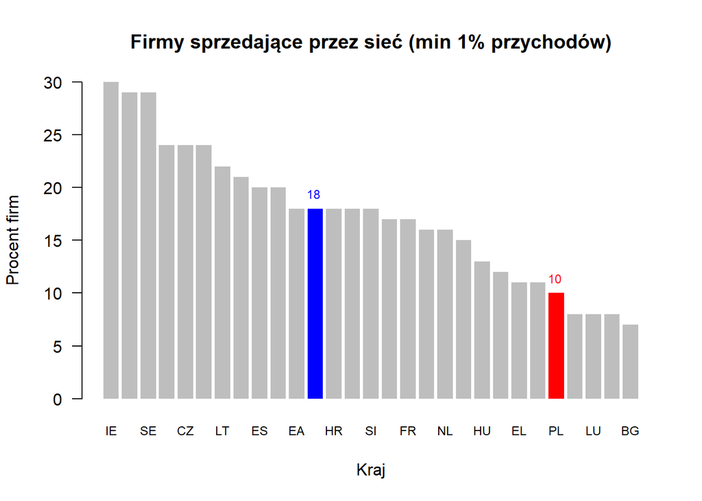

Zmiany zachodzące w czasie pokazują, że sytuacja nie poprawia się - w latach 2010-2017 odsetek polskich firm, które czerpią przychody ze sprzedaży w sieci praktycznie się nie zwiększył, a tymczasem w innych krajach Unii widoczne są systematyczne wzrosty. W ostatnim roku wyprzedziły nas kolejne dwa kraje.

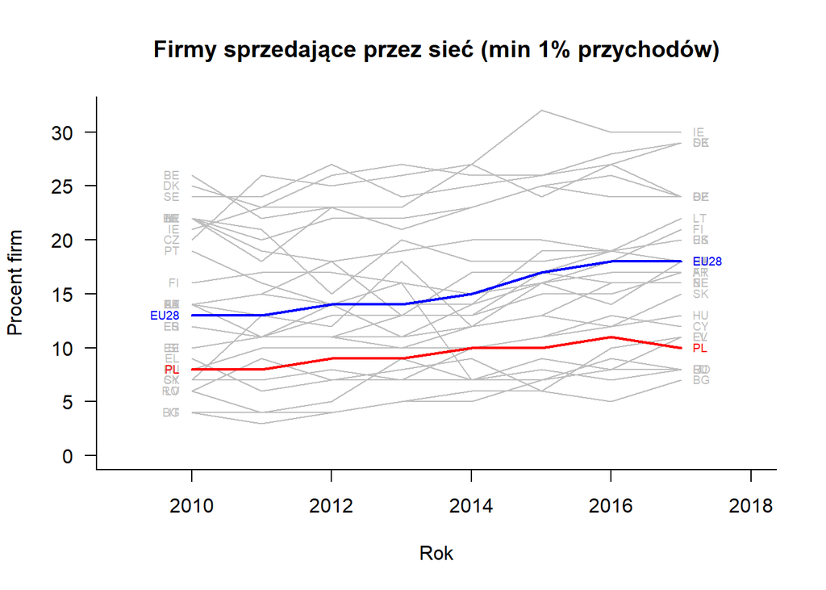

Podobnie jak w przypadku zamówień przez internet, również w przypadku sprzedaży w sieci znacznie lepiej radzą sobie największe firmy, zatrudniające ponad 250 osób. Zdecydowanie odstają za to firmy najmniejsze - tylko w trzech krajach Unii, firmy zatrudniające 10-49 osób rzadziej sprzedają swoje usługi lub towary przez internet.

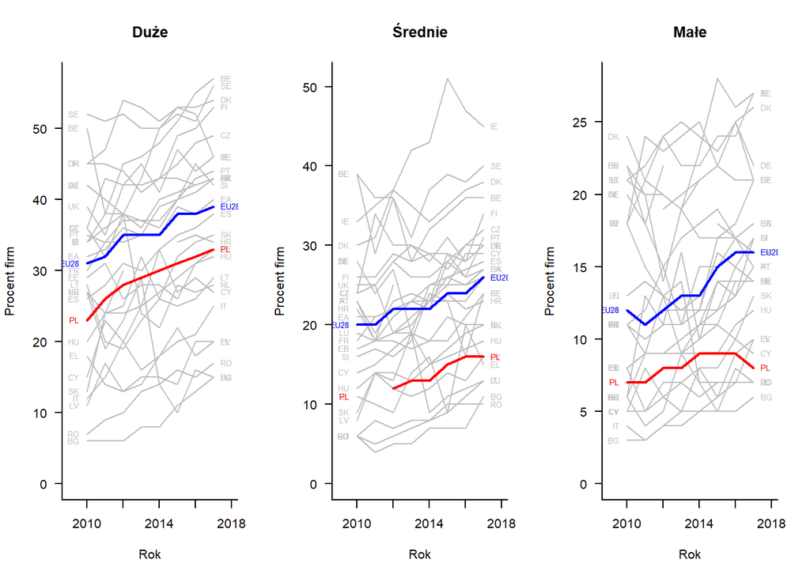

Przedstawione dotychczas wyniki pokazują, że polskie firmy mogą być nieprzygotowane do konkurowania na Jednolitym Rynku Cyfrowym. Aby jednak w pełni zweryfikować tę hipotezę należy sprawdzić jak firmy w różnych krajach radzą sobie ze sprzedażą towarów i usług do innych krajów UE.

## Sprzedaż do krajów UE oraz reszty świata

Zaledwie 4% firm w Polsce sprzedaje swoje towary lub usługi do innych krajów UE poprzez internet. Tymczasem średnia dla firm w UE jest ponad dwa razy wyższa i wynosi 9%. Równie kiepsko wypadamy w przypadku sprzedaży poza Unię.

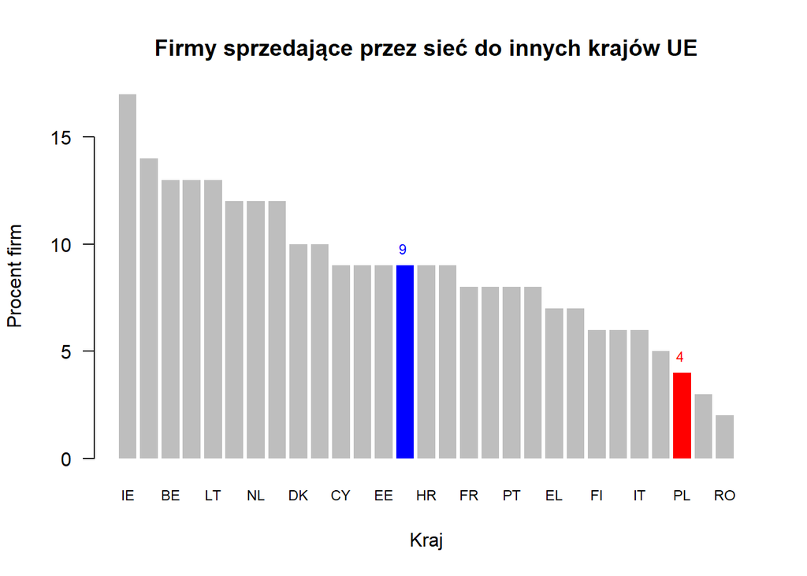

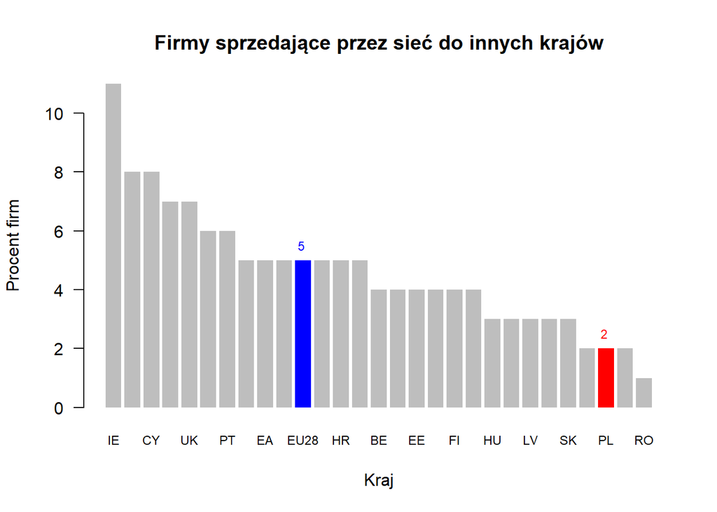

Choć odsetek firm sprzedających przez sieć do innych krajów systematycznie w UE rośnie, to w Polsce zatrzymał się on na poziomie z 2013 roku.

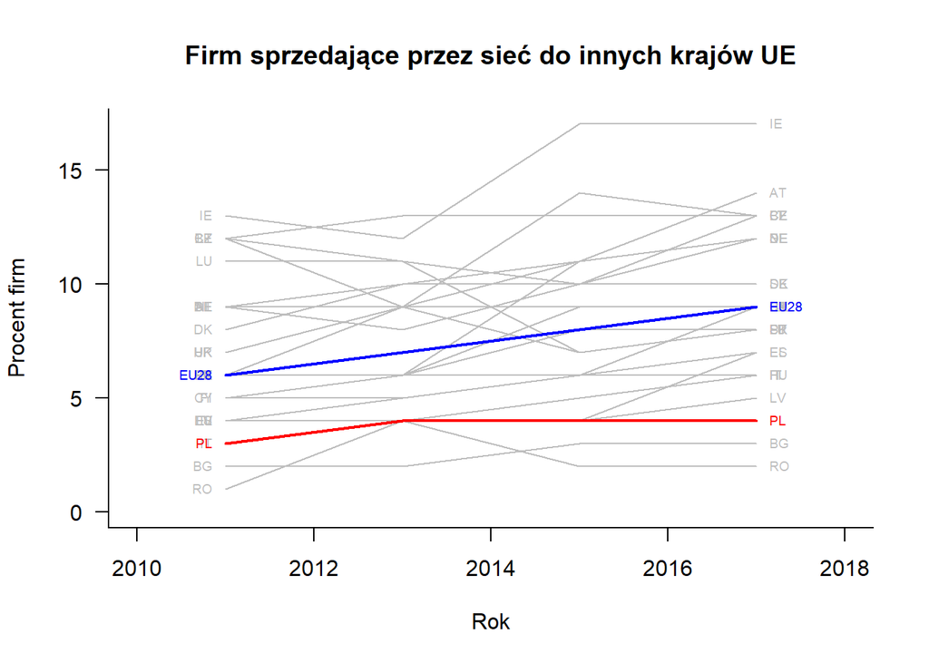

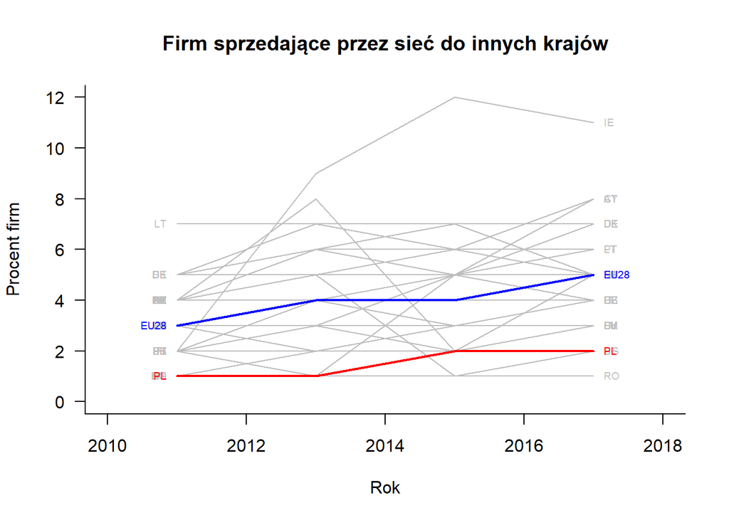

W tym przypadku również największe firmy w mniejszym stopniu niż firmy małe odstają od firm z innych krajów UE.

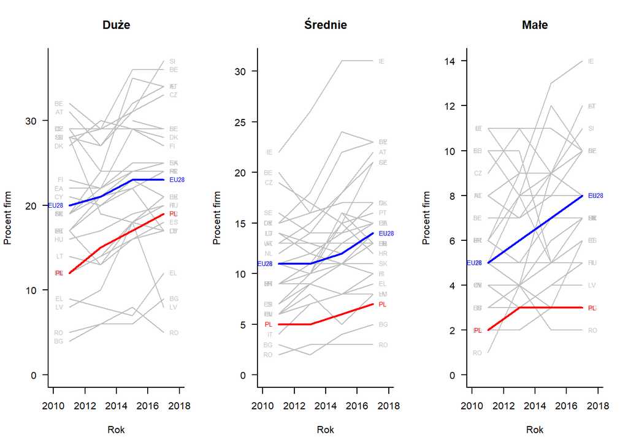

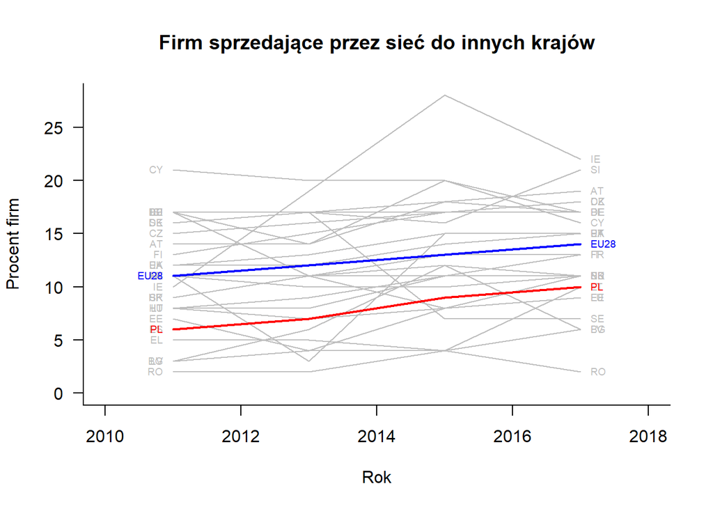

## Uwarunkowania sprzedaży przez sieć

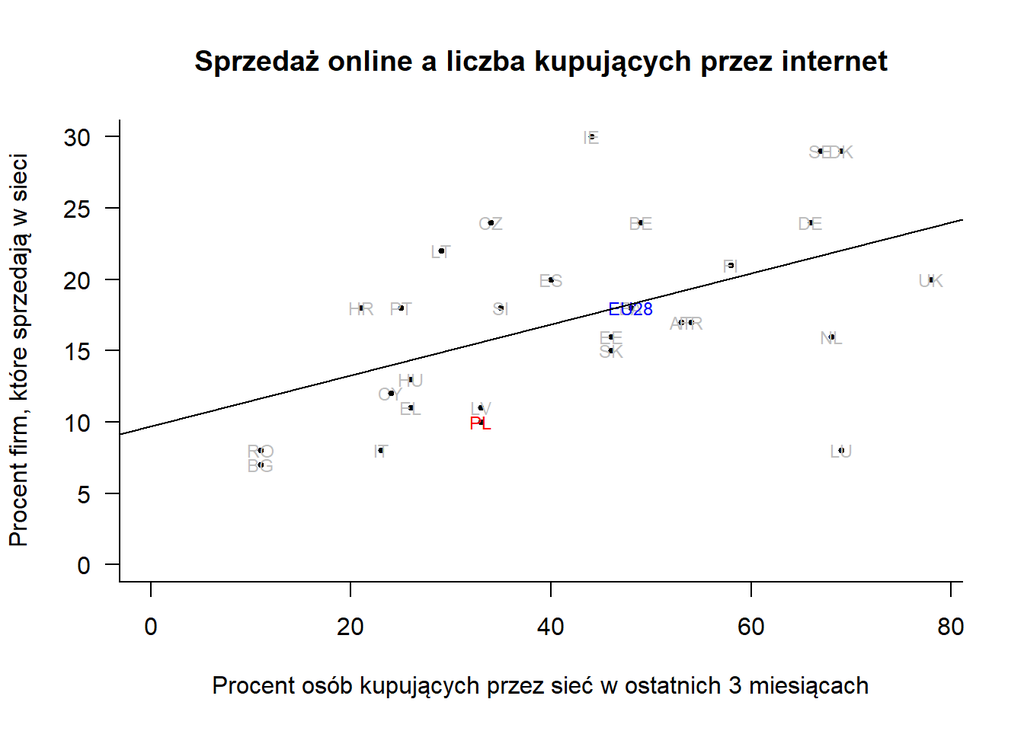

Zdecydowana większość firm w UE ma dostęp do internetu, dlatego też czynnik ten w małym stopniu różnicuje to czy firmy sprzedają w sieci, czy nie.

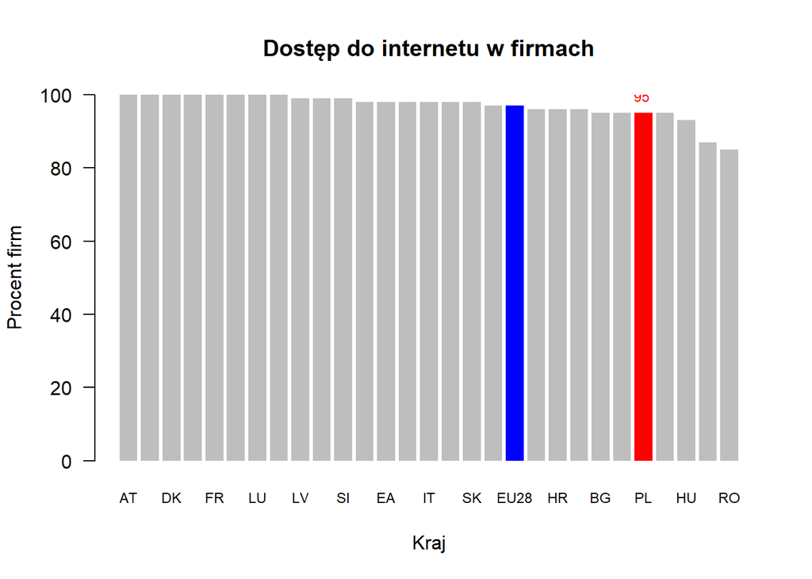

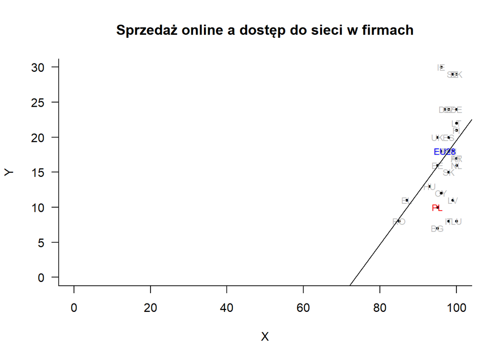

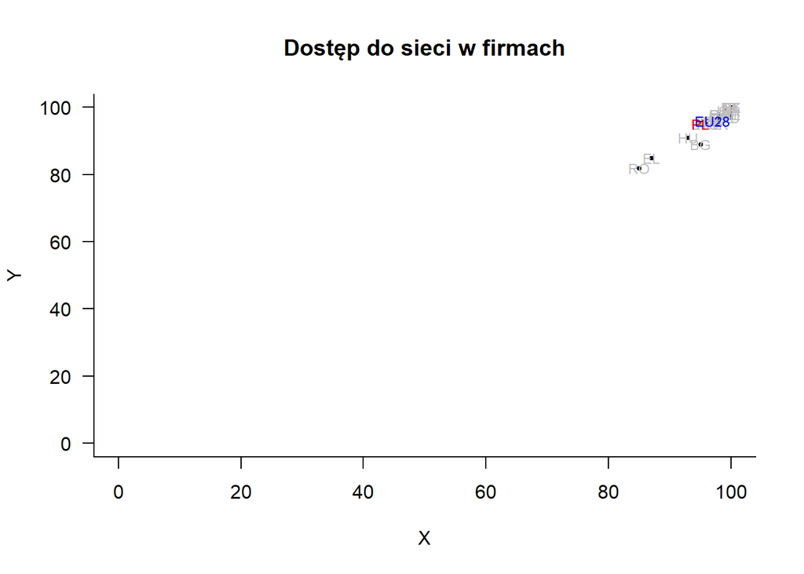